# Exercises Data Science with R

Thomas Kirschstein

# Chapter 7

1. Formulate the Steiner-Weber model with Euclidean distance and solve it with `optim()`.

```r
stein.web.fun <- function(x , cust, a){
  sum(a * apply(cust, 1, function(y) sqrt(sum((y-x)^2)) ) )
}
# number of points/customers
n <- 10
# sample weights
a.vec <- sample(1:100, size = n)
# customer locations
c.mat <- data.frame( x = rnorm(n), y = rnorm(n))
# optimal solution
optim(par = c(0,0), fn = stein.web.fun, method = c("CG"), cust = c.mat, a = a.vec)
```

```
## $par
## [1] -0.4012163  0.8356213
##
## $value
## [1] 206.1165
##
## $counts
## function gradient
##      181       35
##
## $convergence
## [1] 0
##
## $message
## NULL
```

2. Formulate the Newsvendor model and use `optim()` to find the optimal order quantity. Compare the optimal solution found by `optim()` with the theoretical optimum.

```r
# direct optimization
news.vend.fun <- function(x, cu, co, mu, sigma){
  tmp1 <- function(y) co*(x-y)*dnorm(y, mean=mu, sd = sigma)
  tmp2 <- function(y) cu*(y-x)*dnorm(y, mean=mu, sd = sigma)
  integrate(tmp1, lower = 0, upper=x)$value + integrate(tmp2, lower = x, upper=Inf)$value
}

# the elegant way
news.vend.ele.fun <- function(x, cu, co, mu, sigma){
  co*(x - mu) + (cu + co)*sigma*(dnorm((x-mu)/sigma) - ((x-mu)/sigma) * (1- pnorm((x-mu)/sigma)))
}

# example data
mu <- 100
sigma <- 20
co <- .25
cu <- 1

# find optimum
## direct, but slow
system.time(opt.news <- optim(par = 100, fn = news.vend.fun, lower = 0, upper = 200, method="L-BFGS-B", co = co, cu = cu, sigma = sigma, mu=mu))
```

```
##    user  system elapsed
##    0.06    0.00    0.06
## elegant, fast
```

```r
system.time(opt.news.elegant <- optim(par = 100, fn = news.vend.ele.fun, lower = 0, upper = 200, method="L-BFGS-B", co = co, cu = cu, sigma = sigma, mu=mu))
```

```
##    user  system elapsed
##    0.02    0.00    0.02
```

```r
# theoretical optimum
cr <- cu/(cu+co) # critical ratio

q.star <- qnorm(cr, mean=mu, sd = sigma)    # direct
q.star <- mu + sigma * qnorm(cr)                # transformation

# difference numerical vs. theoretical optimum
opt.news$par - q.star
```

```
## [1] 4.076576e-06
```

```r
# --> quite close
```

3. Add an inventory capacity constraint to the Wagner-Whitin model and resolve it with `Rglpk`.

Ad these constraints $l_t \leq cap \qquad \forall t\in T$ to the model.

```r
library(Rglpk)
# assign names to decision vector
n <- 6                              # number of periods
co <- 50                            # ordering cost rate
ch <- 0.1                           # holding cost rate
d.vec <- round(rnorm(n, mean = 100, sd = 20))   # sample demand
bigM <- sum(d.vec)                  # set big M
x.vec <- numeric(3*n + 1)           # initialize decision variables
# right-hand side vector with 200 units inventory capacity
b.vec <- c(d.vec, rep(0, n + 2), rep(200, n) )
# objective coefficients
c.vec <- c(rep(ch, n+1), rep(0, n), rep(co, n))
# vector with constraint directions
const.vec <- c(rep("==", n), rep("<=", n) , rep("==", 2), rep("<=", n) )
# vector with variable types
vtype.vec <- c(rep("C",n + 1), rep("C",n), rep("B",n))
# initialize constraint matrix
A.mat <- matrix(0, ncol = 3*n + 1, nrow = 3*n+2)
# write coefficient in first n rows (inventory constraints)
for(i in 1:n){
  A.mat[i,i]   <- 1         # coefficient for l_{t-1}
  A.mat[i,i+1] <- -1        # coefficient for l_{t}
  A.mat[i,n + 1 + i] <- 1   # coefficient for q_{t}
}
# write coefficient in rows (n+1):(2*n) (ordering constraints)
for(i in (n+1):(2*n)){
  A.mat[i,i+1] <- 1             # coefficient for q_{t}
  A.mat[i,n + 1 + i] <- -bigM   # coefficient for y_{t}
}
# write coefficient in last two rows (inventory initialization)
A.mat[nrow(A.mat)-n-1,1] <- 1    # coefficient for i_{0}
A.mat[nrow(A.mat)-n,n+1] <- 1    # coefficient for i_{T}
# add inventory constraints
for(i in 1:n){
  A.mat[nrow(A.mat)-n+i, i+1] <- 1
}
# solve MILP
sol <- Rglpk_solve_LP(obj = c.vec, mat = A.mat, dir = const.vec, rhs = b.vec, types = vtype.vec)
# list with solution and demand
list( l = sol$solution[1:(n+1)],         # inventory levels
        q = sol$solution[(n+2):(2*n+1)],   # order quantities
        y = tail(sol$solution, n),         # order indicators
        d = d.vec )                        # demand
```

```
## $l
## [1]   0  99   0 119   0 123   0
##
## $q
## [1] 199   0 248   0 234   0
##
## $y
## [1] 1 0 1 0 1 0
##
## $d
## [1] 100  99 129 119 111 123
```

```r
# optimum
sol$optimum
```

```
## [1] 184.1
```

4. Solve the Transshipment Problem with `Rglpk`:
   $$\min\limits_{x_{ij}} \rightarrow \sum_{i \in \mathcal{V}_a }\sum_{j \in \mathcal{V}_t } c_{ij} \cdot x_{ij} + \sum_{j \in \mathcal{V}_t }\sum_{k \in \mathcal{V}_b } c_{jk} \cdot x_{jk}$$
   $$\begin{align}
   \sum_{j \in \mathcal{V}_t} x_{ij} & \leq a_i & \forall i \in \mathcal{V}_a \\
   \sum_{j \in \mathcal{V}_t} x_{jk} & \geq b_k & \forall k \in \mathcal{V}_b \\
   \sum_{i \in \mathcal{V}_a} x_{ij} & = \sum_{k \in \mathcal{V}_b} x_{jk} & \forall j \in \mathcal{V}_t \\
   x_{ij} & \geq 0 \\
   \end{align}$$
   where $a_i$ is the maximum supply capacity of node $i \in \mathcal{V}_a$, $b_k$ denotes the demand of node $j \in \mathcal{V}_b$, $c_{ij/jk}$ are transport cost rates and $x_{ij/jk}$ are shipment quantities.

```r
n.a <- 4                            # number sources
n.b <- 5                            # number sinks
n.t <- 3                            # number terminals
nam.A <- paste("A",1:n.a, sep="")
nam.B <- paste("B",1:n.b, sep="")
nam.T <- paste("T",1:n.t, sep="")
# sample demand & supply
repeat{
  d.vec <- round(runif(n.b, min = 100, max = 200))
  s.vec <- round(runif(n.a, min = 150, max = 250))
  # check for sufficient supply
  if(sum(d.vec) < sum(s.vec)) break
}
# sample distances
## sources-terminals
d.a.t <- round(runif(n.a*n.t, min = 1, max = 50))
## terminals-sinks
d.t.b <- round(runif(n.b*n.t, min = 1, max = 30))
# initialize decision variables
x.vec <- numeric(n.a*n.t + n.b*n.t)
# right-hand side vector
b.vec <- c(s.vec, d.vec, rep(0, n.t) )
# objective coefficients
c.vec <- c(d.a.t, d.t.b)
# vector with constraint directions
const.vec <- c(rep("<=", n.a), rep(">=", n.b) , rep("==", n.t) )
# vector with variable types
vtype.vec <- rep("C", length(x.vec))
# constraint matrix A
A.mat <- matrix(0, ncol = length(x.vec), nrow = n.a + n.b + n.t)
# use variable names
colnames(A.mat) <- c(
  apply(expand.grid(nam.A, nam.T), 1, paste, collapse="-"),
  apply(expand.grid(nam.T, nam.B), 1, paste, collapse="-")
)
# iteratively add constraints via name matching
# supply constraints
t.id <- 1
for(i in 1:n.a){
  A.mat[t.id, grepl(nam.A[i] , colnames(A.mat) )  ] <- 1
  t.id <- t.id + 1
}
# demand constraints
for(i in 1:n.b ){
    A.mat[t.id, grepl(nam.B[i] , colnames(A.mat) )  ] <- 1
    t.id <- t.id + 1
}
# terminal constraints
for(i in 1:n.t ){
    A.mat[t.id, grepl(nam.T[i] , colnames(A.mat) )  ] <- rep( c(1,-1), times=c(n.a, n.b) )
    t.id <- t.id + 1
}

# solve MILP
sol.uncnst <- Rglpk_solve_LP(obj = c.vec, mat = A.mat, dir = const.vec, rhs = b.vec, types = vtype.vec, control =list("verbose" = T) )
## GLPK Simplex Optimizer, v4.47
## 12 rows, 27 columns, 54 non-zeros
##       0: obj =  0.000000000e+000  infeas = 8.030e+002 (3)
## *    11: obj =  4.654100000e+004  infeas = 0.000e+000 (0)
## *    20: obj =  1.997900000e+004  infeas = 0.000e+000 (0)
## OPTIMAL SOLUTION FOUND
ship.uncnst <- sol.uncnst$solution
names(ship.uncnst) <- colnames(A.mat)
```

1. How would you cope with transshipment capacities at nodes $j \in \mathcal{V}_t$?

Add constraints with terminal capacity $d_j$:

$$\sum_{i \in \mathcal{V_a} } x_{ij} \leq d_j \qquad \forall j \in \mathcal{V_t}$$

```r
# sample capacities
repeat{
  cap.vec <- round(runif(n.t, min = 150, max = 275))
  # check for sufficient supply
  if(sum(d.vec) < sum(cap.vec)) break
}
# right-hand side vector
b.vec.cap <- c(s.vec, d.vec, rep(0, n.t), cap.vec )
# vector with constraint directions
const.vec.cap <- c(rep("<=", n.a), rep(">=", n.b) , rep("==", n.t),  rep("<=", n.t))
# constraint matrix A
A.mat.cap <- matrix(0, ncol = length(x.vec), nrow = n.a + n.b + 2*n.t )
# use variable names
colnames(A.mat.cap) <- c(
  apply(expand.grid(nam.A, nam.T), 1, paste, collapse="-"),
  apply(expand.grid(nam.T, nam.B), 1, paste, collapse="-")
)
# iteratively add constraints via name matching
# supply constraints
t.id <- 1
for(i in 1:n.a){
  A.mat.cap[t.id, grepl(nam.A[i] , colnames(A.mat.cap) )  ] <- 1
  t.id <- t.id + 1
}
# demand constraints
for(i in 1:n.b ){
  A.mat.cap[t.id, grepl(nam.B[i] , colnames(A.mat.cap) )  ] <- 1
    t.id <- t.id + 1
}
# terminal constraints
for(i in 1:n.t ){
  A.mat.cap[t.id, grepl(nam.T[i] , colnames(A.mat.cap) )  ] <- rep( c(1,-1), times=c(n.a, n.b) )
    t.id <- t.id + 1
}
# capacity constraints
for(i in 1:n.t ){
  A.mat.cap[t.id, grepl( paste("A*-",nam.T[i],sep="") , colnames(A.mat.cap) )  ] <- 1
    t.id <- t.id + 1
}
# solve MILP
sol.cap <- Rglpk_solve_LP(obj = c.vec, mat = A.mat.cap, dir = const.vec.cap, rhs = b.vec.cap, types = vtype.vec, control =list("verbose" = T, "presolve" = T) )
## GLPK Simplex Optimizer, v4.47
## 15 rows, 27 columns, 66 non-zeros
## Preprocessing...
## 15 rows, 27 columns, 66 non-zeros
## Scaling...
##  A: min|aij| = 1.000e+000  max|aij| = 1.000e+000  ratio = 1.000e+000
## Problem data seem to be well scaled
## Constructing initial basis...
## Size of triangular part = 15
##       0: obj =  0.000000000e+000  infeas = 8.030e+002 (0)
## *    12: obj =  3.508700000e+004  infeas = 0.000e+000 (0)
## *    23: obj =  2.654500000e+004  infeas = 0.000e+000 (0)
## OPTIMAL SOLUTION FOUND
ship.cap <- sol.cap$solution
names(ship.cap) <- colnames(A.mat)
# compare solutions
## cost - effect
sol.cap$optimum - sol.uncnst$optimum
```

```
## [1] 6566
## solution
```

```r
data.table(rbind(ship.cap, ship.uncnst))
```

| A1-T1 | A2-T1 | A3-T1 | A4-T1 | A1-T2 | A2-T2 | A3-T2 | A4-T2 | A1-T3 | A2-T3 | A3-T3 | A4-T3 | T1-B1 | T2-B1 | T3-B1 | T1-B2 | T2-B2 | T3-B2 | T1-B3 | T2-B3 | T3-B3 | T1-B4 | T2-B4 | T3-B4 | T1-B5 | T2-B5 | T3-B5 |
| --- | --- | --- | --- | --- | --- | --- | --- | --- | --- | --- | --- | --- | --- | --- | --- | --- | --- | --- | --- | --- | --- | --- | --- | --- | --- | --- |
| 15 | 242 | 0 | 0 | 0 | 0 | 41 | 233 | 135 | 0 | 137 | 0 | 0 | 0 | 187 | 183 | 0 | 0 | 25 | 143 | 0 | 49 | 0 | 85 | 0 | 131 | 0 |
| 0 | 0 | 0 | 0 | 0 | 242 | 0 | 57 | 236 | 0 | 178 | 90 | 0 | 0 | 187 | 0 | 0 | 183 | 0 | 168 | 0 | 0 | 0 | 134 | 0 | 131 | 0 |

2. How would you cope with fixed transshipment costs?

Change objective function by introducing binary variables $\alpha_j \in \{0,1\}$ and transshipment cost $c^{TS}_j$

$$\min\limits_{x_{ij}} \rightarrow \sum_{i \in \mathcal{V}_a }\sum_{j \in \mathcal{V}_t } c_{ij} \cdot x_{ij} + \sum_{j \in \mathcal{V}_t }\sum_{k \in \mathcal{V}_b } c_{jk} \cdot x_{jk} + \sum_{j \in \mathcal{V_t}} \alpha_j \cdot c^{TS}_j$$
Additionally, constraints for assigning the correct values of $\alpha_j$ have to be added:

$$\sum_{i \in \mathcal{V_a} } x_{ij} \leq \alpha_j \cdot d_j$$

```r
# sample transshipment cost
c.ts.vec <- round(runif(n.t, min = 5000, max = 10000))

x.vec.ts <- numeric(n.a*n.t + n.b*n.t + n.t)
# right-hand side vector
b.vec.ts <- c(s.vec, d.vec, rep(0, 2*n.t) )
# objective coefficients
c.vec.ts <- c(d.a.t, d.t.b, c.ts.vec)
# vector with constraint directions
const.vec.ts <- c(rep("<=", n.a), rep(">=", n.b) , rep("==", n.t) , rep("<=", n.t))
# vector with variable types
vtype.vec.ts <- c( rep("C", n.a*n.t + n.b*n.t), rep("B", n.t) )
# constraint matrix
A.mat.ts <- matrix(0, ncol = length(x.vec.ts), nrow = n.a + n.b + 2*n.t)
# use variable names
colnames(A.mat.ts) <- c(
  apply(expand.grid(nam.A, nam.T), 1, paste, collapse="-"),
  apply(expand.grid(nam.T, nam.B), 1, paste, collapse="-"),
  paste("alpha-", 1:n.t, sep = "")
)
# iteratively add constraints via name matching
# supply constraints
t.id <- 1
for(i in 1:n.a){
  A.mat.ts[t.id, grepl(nam.A[i] , colnames(A.mat.ts) )  ] <- 1
  t.id <- t.id + 1
}
# demand constraints
for(i in 1:n.b ){
  A.mat.ts[t.id, grepl(nam.B[i] , colnames(A.mat.ts) )  ] <- 1
    t.id <- t.id + 1
}
# terminal constraints
for(i in 1:n.t ){
  A.mat.ts[t.id, grepl(nam.T[i] , colnames(A.mat.ts) )  ] <- rep( c(1,-1), times=c(n.a, n.b) )
    t.id <- t.id + 1
}
# capacity constraints
for(i in 1:n.t ){
  A.mat.ts[t.id, grepl( paste("A*-", nam.T[i], sep = "") , colnames(A.mat.ts) )  ] <- 1
  A.mat.ts[t.id, grepl( paste("alpha-", i, sep = "") , colnames(A.mat.ts) )  ] <- -cap.vec[i]
   t.id <- t.id + 1
}
# solve MILP
sol.ts <- Rglpk_solve_LP(obj = c.vec.ts, mat = A.mat.ts, dir = const.vec.ts, rhs = b.vec.ts, types = vtype.vec.ts, control = list("verbose" =TRUE))
## GLPK Simplex Optimizer, v4.47
## 15 rows, 30 columns, 69 non-zeros
##       0: obj =  0.000000000e+000  infeas = 8.030e+002 (3)
## *    17: obj =  6.367436923e+004  infeas = 0.000e+000 (0)
## *    28: obj =  5.096336923e+004  infeas = 0.000e+000 (0)
## OPTIMAL SOLUTION FOUND
## GLPK Integer Optimizer, v4.47
## 15 rows, 30 columns, 69 non-zeros
## 3 integer variables, all of which are binary
## Integer optimization begins...
## +    28: mip =     not found yet >=              -inf        (1; 0)
## +    31: >>>>>  5.107100000e+004 >=  5.107100000e+004   0.0% (1; 0)
## +    31: mip =  5.107100000e+004 >=     tree is empty   0.0% (0; 1)
## INTEGER OPTIMAL SOLUTION FOUND
ship.ts <- sol.ts$solution
names(ship.ts) <- colnames(A.mat.ts)
# compare solutions
## cost - effect
sol.ts$optimum
```

```
## [1] 51071
```

```r
sol.cap$optimum
```

```
## [1] 26545
```

```r
sol.uncnst$optimum
```

```
## [1] 19979
## solution
```

```r
data.table(rbind(ship.cap, ship.uncnst, ship.ts[1:27]))
```

| A1-T1 | A2-T1 | A3-T1 | A4-T1 | A1-T2 | A2-T2 | A3-T2 | A4-T2 | A1-T3 | A2-T3 | A3-T3 | A4-T3 | T1-B1 | T2-B1 | T3-B1 | T1-B2 | T2-B2 | T3-B2 | T1-B3 | T2-B3 | T3-B3 | T1-B4 | T2-B4 | T3-B4 | T1-B5 | T2-B5 | T3-B5 |
| --- | --- | --- | --- | --- | --- | --- | --- | --- | --- | --- | --- | --- | --- | --- | --- | --- | --- | --- | --- | --- | --- | --- | --- | --- | --- | --- |
| 15 | 242 | 0 | 0 | 0 | 0 | 41 | 233 | 135 | 0 | 137 | 0 | 0 | 0 | 187 | 183 | 0 | 0 | 25 | 143 | 0 | 49 | 0 | 85 | 0 | 131 | 0 |
| 0 | 0 | 0 | 0 | 0 | 242 | 0 | 57 | 236 | 0 | 178 | 90 | 0 | 0 | 187 | 0 | 0 | 183 | 0 | 168 | 0 | 0 | 0 | 134 | 0 | 131 | 0 |
| 0 | 242 | 15 | 0 | 0 | 0 | 41 | 233 | 150 | 0 | 122 | 0 | 0 | 0 | 187 | 183 | 0 | 0 | 25 | 143 | 0 | 49 | 0 | 85 | 0 | 131 | 0 |

5. Change the problem by adding constraints that prohibit the center to be closer than 0.5 distance units to any point.

```r
library(ROI)            # load package
## ROI: R Optimization Infrastructure
## Registered solver plugins: nlminb, alabama, clp, deoptimr, deoptim, ecos, glpk, neos, nloptr.bobyqa, nloptr.crs2lm, nloptr.direct, nloptr.directL, nloptr.lbfgs, nloptr.neldermead, nloptr.newuoa, nloptr.sbplx, nloptr.stogo, nloptr.tnewton, nloptr.varmetric, nloptr.cobyla, nloptr.mma, nloptr.auglag, nloptr.isres, nloptr.slsqp, quadprog, symphony.
## Default solver: auto.
# solver for non-linear, generally constrained programs
library(ROI.plugin.alabama)

n <- 100
# sample weights for each point/customer
a.vec <- sample(1:100, size = n)
# sample x coordinates
x.vec <- rnorm(n)
# sample y coordinates
y.vec <- rnorm(n)
# Set up optimization program
copt <- OP(
  objective = F_objective(F = function(loc) sum(a.vec * (abs(x.vec - loc[1]) + abs(y.vec - loc[2]) ) ), n = 2),
  types = rep("C", 2),
  bounds = V_bound(ub = rep(Inf, 2), lb = rep(-Inf, 2)),
  constraints = F_constraint(
      F = function(loc) min( (abs(x.vec - loc[1]) + abs(y.vec - loc[2]) ) ),
      dir = ">=",
      rhs = 0.5)
)
# solve the problem
sol.cnst <- ROI_solve(copt, start = c(0,0), solver = "alabama")
 # obtain solution
sol <- sol.cnst$solution
# objective value
sol.cnst$objval
```

```
## [1] 10819.98
```

```r
# check constraint
min(abs(x.vec - sol[1]) + abs(y.vec - sol[2]))
```

```
## [1] 0.5
```

```r
# unconstrained solution
constraints(copt) <- NULL
sol.uncnst <- ROI_solve(copt, start = c(0,0))
# compare objective values
sol.cnst$objval - sol.uncnst$objval
```

```
## [1] 2996.094
```

```r
# compare solutions
rbind(sol.cnst$solution, sol.uncnst$solution)
```

```
##             [,1]       [,2]
## [1,] -0.97050128 -0.9171823
## [2,] -0.07737983 -0.1338614
```

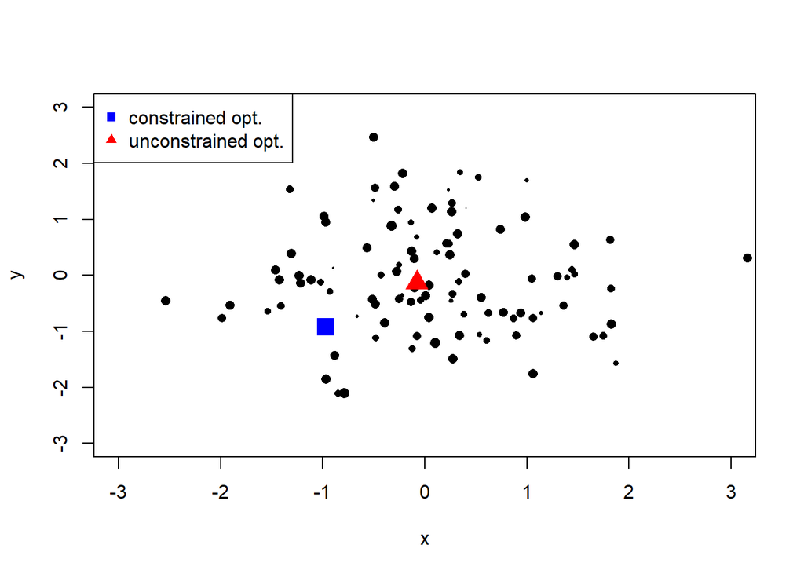

```r
# plot solutions
plot(x.vec, y.vec, xlab="x", ylab="y", cex = log(a.vec)/4, pch=16, ylim=c(-3,3), xlim=c(-3,3))
points(rbind(sol.cnst$solution,sol.cnst$solution), col="blue", cex=2, pch =15)
points(rbind(sol.uncnst$solution,sol.uncnst$solution), col="red", cex=2, pch =17)
legend("topleft", pch=c(15,17), col=c("blue","red"), legend=c("constrained opt.","unconstrained opt."))
```

6. Formulate the Newsvendor model with $\beta$ service level restriction with the `ROI` framework.

```r
# first order loss function
l.fun <- function(x) {
  sigma * (dnorm((x-mu)/sigma) - (x-mu)/sigma * (1-pnorm((x-mu)/sigma) ))
}

# example data
mu <- 100
sigma <- 20
co <- .75
cu <- 1
beta <- 0.975

copt <- OP(
  objective = F_objective(F = function(x) co*(x - mu) + (cu + co)*sigma*(dnorm((x-mu)/sigma) - ((x-mu)/sigma) * (1- pnorm((x-mu)/sigma))) , n = 1),
  types = rep("C", 1),
  bounds = V_bound(ub = rep(Inf, 1), lb = rep(1, 1)),
  constraints = F_constraint(
      F = function(x) (1 - l.fun(x)/mu),
      dir = ">=",
      rhs = beta)
)
# beta-constrained solution
sol <- ROI_solve(copt, start = mu, solver = "alabama")
# optimal q
sol$solution
```

```
## [1] 115.5544
```

```r
# cost
sol$objval
```

```
## [1] 16.04078
```

```r
# cost-opt solution
constraints(copt) <- NULL
sol.cost <- ROI_solve(copt, start = mu)
# optimal q
sol.cost$solution
```

```
## [1] 103.6002
```

```r
# cost
sol.cost$objval
```

```
## [1] 13.73857
```

7. Formulate the constraint matrix `L` as a sparse matrix.

```r
# create problem dimension
n <- 10
# create cost vector
c.vec <- rpois(n^2, 100)
# decision vector
x.vec <- numeric(n^2)
names(x.vec) <- apply(expand.grid(paste("i", 1:n, sep=""), paste("j", 1:n, sep="")),1, function(x) paste(x, collapse = "-"))
# constraint matrix
nb.const <- 1
const.mat <- NULL
for(i in 1:10){
  tmp.ind.row <- rep(nb.const, n)
  tmp.ind.col <- which(grepl(paste("-j",i,"$",sep="") , names(x.vec)))
  tmp.const <- rep(1, n)
  const.mat <- rbind(const.mat, cbind(tmp.ind.row, tmp.ind.col, tmp.const)) # update constraint data frame
  nb.const <- 1 + nb.const
}
for(i in 1:10){
  tmp.ind.row <- rep(nb.const, n)
  tmp.ind.col <- which(grepl(paste("i",i,"-",sep="") , names(x.vec)))
  tmp.const <- rep(1, n)
  const.mat <- rbind(const.mat, cbind(tmp.ind.row, tmp.ind.col, tmp.const)) # update constraint data frame
  nb.const <- 1 + nb.const
}
# write as sparse matrix
library(Matrix)
A.mat <- sparseMatrix(i = const.mat[,1],
                      j = const.mat[,2],
                      x = const.mat[,3],
                      dims = c(2*n , n^2),
                      giveCsparse = T)
# Solution via RGLPK
sol <- Rglpk_solve_LP(obj = c.vec, mat = A.mat, dir = rep("==", 2*n), rhs = rep(1, 2*n), types = rep("B", n^2))

#############################################################
# Alternative: ROI package requires a different sparse matrix class,
# but syntax is almost the same
library(slam)
A.mat.slam <- simple_triplet_matrix(i = const.mat[,1],
                               j = const.mat[,2],
                               v = const.mat[,3],
                               nrow = 2*n, ncol = n^2)

copt <- OP(
  objective = L_objective(L = c.vec),
  types = rep("B", n^2),
  constraints = L_constraint(L = A.mat.slam,
                             dir = rep("==", 2*n),
                             rhs = rep(1, 2*n)))
# solve the problem
sol.roi <- ROI_solve(copt)

# check equality
all(sol.roi$solution == sol$solution)
```

```
## [1] TRUE
```

```r
sol$optimum == sol.roi$objval
```

```
## [1] TRUE
```

```r
# display solution in matrix form
sol.mat <- matrix(sol$solution, ncol = n)
# check first set of constraints
colSums(sol.mat)                    # all column sums equal to 1?
```

```
##  [1] 1 1 1 1 1 1 1 1 1 1
```

```r
# check second set of constraints
rowSums(sol.mat)                    # all row sums equal to 1?
```

```
##  [1] 1 1 1 1 1 1 1 1 1 1
```

```r
# check objective
sum(sol.mat * matrix(c.vec, ncol = n))
```

```
## [1] 891
```

8. Implement the quadratic assignment problem with `ROI`. Can you reuse parts of the linear assignment problem?

Essentially, the objective function has to be altered such that

$$\min \rightarrow \sum_{i=1}^n\sum_{j=1}^{n} \sum_{k=1}^n\sum_{l=1}^{n} x_{ij} \cdot x_{kl} \cdot f_{ik} \cdot d_{jl}$$

```r
# sample flow matrix
flow.mat <- matrix(sample(10:100, n^2, replace=T) , ncol=n)
# sample dist matrix
dist.mat <- round(matrix(rnorm(n^2, mean = 5, sd = 1) , ncol=n),1)
diag(dist.mat) <- 0
dist.mat[upper.tri(dist.mat)] <- t(dist.mat)[upper.tri(dist.mat)]
# quadratic assignment problem
quad.ass.obj.fun <- function(x){
  # the elegant way
  tmp.ass.mat <- matrix(x, ncol = sqrt(length(x)) )
  sum(diag(flow.mat %*% tmp.ass.mat %*% dist.mat %*% t(tmp.ass.mat)))
  # direct way
  #tmp <- apply(tmp.ass.mat,1, function(x) which(x==1))
  #sum(as.numeric(flow.mat) * dist.mat[as.matrix(expand.grid(tmp, tmp))])
}

copt <- OP(
  objective = F_objective(F = quad.ass.obj.fun, n = n^2),
  types = rep("B", n^2),
  constraints = L_constraint(L = A.mat.slam,
                             dir = rep("==", 2*n),
                             rhs = rep(1, 2*n)))
# solve the problem
# sol.roi <- ROI_solve(copt)
# no solver --> remedy?
```

9. The function for accessing the distances is obtained from [here](https://www.r-orms.org/mixed-integer-linear-programming/practicals/problem-tsp/). Try to formulate a more compact `dist_fun()`.

–> postponed

10. Implement and solve the Wagner-Whithin model introduced above with `ompr`.

```r
library(ompr)
library(dplyr)
library(ompr.roi)
library(ROI.plugin.glpk)
# number of periods
n <- 10
# sample demand
d.vec <- round(runif(n, min = 10 , max = 50))
# ordering cost
co <- 100
# stock holding cost
ch <- 1

model <- MIPModel() %>%
  # add order quantity variable
  add_variable(x[i], i = 1:n, type = "continuous", lb = 0, ub = sum(d.vec)) %>%
  # stock level variable
  add_variable(l[i], i = 0:n, type = "continuous", lb = 0, ub = sum(d.vec)) %>%
  # order indicator variable
  add_variable(a[i], i = 1:n, type = "binary", lb = 0, ub = 1) %>%
  # objective function
  set_objective(sum_expr(l[i] * ch + a[i] * co, i = 1:n), "min") %>%
  # stock initialization
  add_constraint(l[0] == 0) %>%
  # stock balance constraints
  add_constraint(l[i] == l[i-1] + x[i] - d.vec[i], i = 1:n) %>%
  # order indicator constraint
  add_constraint(x[i] <= a[i] * sum(d.vec), i = 1:n)

# solve model with GLPK
result <- solve_model(model, with_ROI(solver = "glpk", verbose = TRUE))
## <SOLVER MSG>  ----
## GLPK Simplex Optimizer, v4.47
## 21 rows, 31 columns, 51 non-zeros
##       0: obj =  0.000000000e+000  infeas = 2.630e+002 (11)
## *    21: obj =  1.000000000e+002  infeas = 0.000e+000 (0)
## OPTIMAL SOLUTION FOUND
## GLPK Integer Optimizer, v4.47
## 21 rows, 31 columns, 51 non-zeros
## 10 integer variables, all of which are binary
## Integer optimization begins...
## +    21: mip =     not found yet >=              -inf        (1; 0)
## +    23: >>>>>  1.217000000e+003 >=  2.889733840e+002  76.3% (10; 0)
## +    26: >>>>>  7.560000000e+002 >=  2.963117871e+002  60.8% (17; 1)
## +    27: >>>>>  7.290000000e+002 >=  3.129315589e+002  57.1% (20; 8)
## +    32: >>>>>  6.250000000e+002 >=  3.894676806e+002  37.7% (35; 12)
## +    48: >>>>>  6.230000000e+002 >=  4.782471483e+002  23.2% (58; 36)
## +    63: >>>>>  5.910000000e+002 >=  5.100912548e+002  13.7% (72; 51)
## +    76: >>>>>  5.890000000e+002 >=  5.422471483e+002   7.9% (36; 112)
## +    78: >>>>>  5.810000000e+002 >=  5.810000000e+002   0.0% (13; 170)
## +    78: mip =  5.810000000e+002 >=     tree is empty   0.0% (0; 229)
## INTEGER OPTIMAL SOLUTION FOUND
## <!SOLVER MSG> ----
# total cost
result$objective_value
```

```
## [1] 581
```

```r
#
# # obtain solution
solution <- get_solution(result, x[i])
solution <- data.frame(solution[-1] , demand = d.vec)
colnames(solution)[1:2] <- c("period","order quant.")
solution
```

| period | order quant. | demand |
| --- | --- | --- |
| 1 | 43 | 19 |
| 2 | 0 | 24 |
| 3 | 54 | 18 |
| 4 | 0 | 19 |
| 5 | 0 | 17 |
| 6 | 95 | 47 |
| 7 | 0 | 48 |
| 8 | 71 | 38 |
| 9 | 0 | 10 |
| 10 | 0 | 23 |